# Predicting how well exercise is performed using sensor data

Ines Vidal Castiñeira

## Executive Summary

The HAR dataset contains measures of accelerometers worn by by six individuals while performing barbell lifts correctly and in five incorrect ways. Using this data we predict how well (in which manner) the exercise is done. The study starts by reducing the dataset dimension, keeping only relevant variables. Then, to be able to assess out of sample error, the training dataset is divided in two, *train* and *test*. Using a sample of the train dataset the relationships between variables are studied and several models tested (random tree, random forest with and without PCA) and the one with the highest accuracy (and reasonable performance) in the *test* dataset is selected. Using random forest the type of execution of the exercise is predicted with high accuracy.

## Data cleaning

First we review sparsity, and remove rows without any informed value and columns with over 95% uninformed values (they coincide with columns that are only recorded when variable *new_window*=“yes”). Finally we exclude columns *row.names*, *X*, *user_name*, *raw_timestamp_part_1*, *raw_timestamp_part_2*, *cvtd_timestamp*, *new_window* and *num_window*, that are considered irrelevant to the experiment.

That leaves us with a smaller dataset (19622 observations and 53 variables), in principle equally relevant in modelling terms, and easier to work with in terms of performance.

We decided to keep the test dataset for final validation, and subdivide the clean training set into a training set and a test set, so that we can assess out of sample error. The table below represents the different sets:

**Table 1**: Original datasets, and sets considered for the study

|  | Original training dataset | Original testing | Clean Training dataset | Train set | Test set | Validate set |
| --- | --- | --- | --- | --- | --- | --- |
| **Observations** | 19622 | 20 | 19622 | 19585 | 37 | 20 |
| **Variables** | 160 | 160 | 53 | 53 | 53 | 53 |

## Data Exploration

Initial tests showed that execution times using the complete *train set* are very long, so we decided to proceed with a 1% sample (198, 53) observations), to assess model performance, and go ahead with final prediction only with the models that show good results,

The study of how interrelated variables are is shown in the figure below:

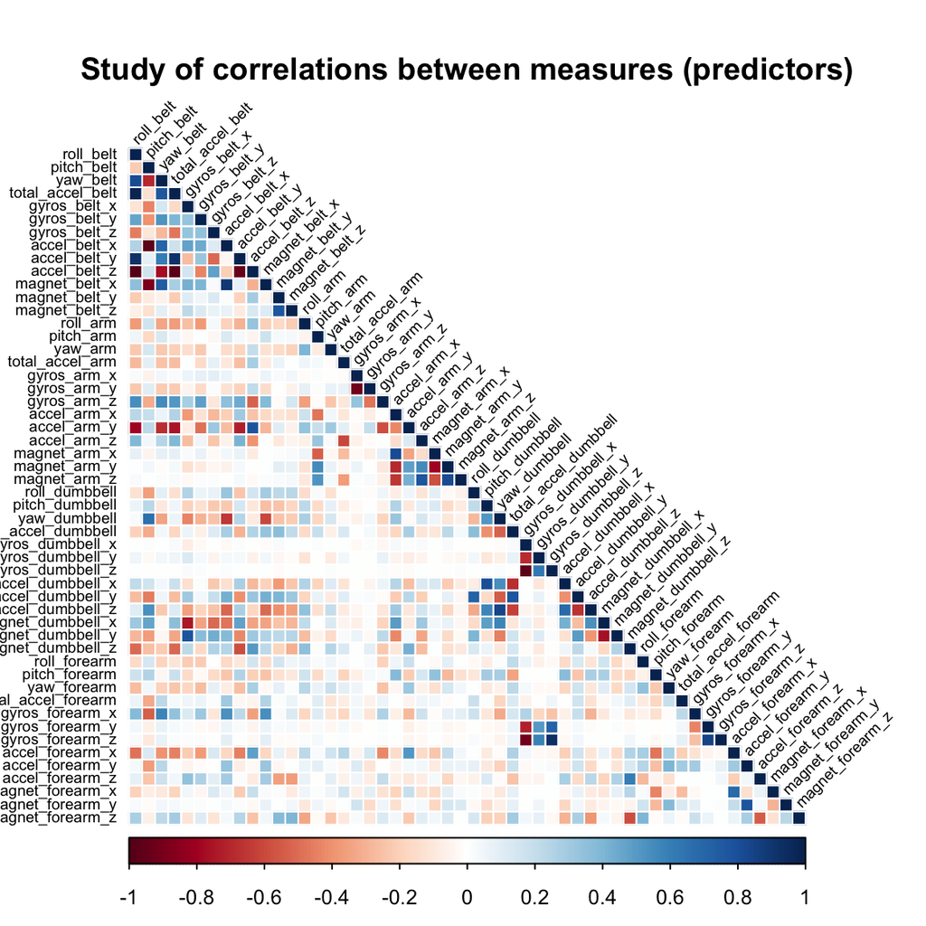

Considering the number of dark cells (high correlation), a Principal Components analysis was considered as an option to help identify the main variables to consider in the model, to reduce its complexity (and execution/training time).

The following table presents the conclusions of model comparison:

**Table 2**: Models accuracy comparison using 1% sample of ‘train set’

|  | Accuracy | Execution time |
| --- | --- | --- |
| **Trees (caret-rpart)** | 0.4324 | 2.469 |
| **Boosting (caret-gbm)** | 0.6757 | 24.33 |
| **Linear Discriminant analysis (caret-lda)** | 0.5405 | 1.025 |
| **Naive Bayes (caret-nb)** | 0.4865 | 46.05 |
| **random forest (randomForest)** | 0.7297 | 0.429 |
| **PCA + random forest (randomForest)** | 0.5676 | 24.3 |
| **PCA + random forest (caret-rf)** | 1 | 20.13 |
| **Random forest w/c.variance (caret-rf)** | 0.7027 | 13.02 |
| **PCA + Random forest w/c.variance (caret-rf)** | 0.6216 | 9.237 |

To select final model two criteria have been considered a) the accuracies associated to the models (that we assume will be higher when 100% of the *train set* is considered), and b) the time required to run the model (that will be much higher with the complete *train set*). In this sense, the model with highest accuracy did not run in reasonable time using the *train set*. The model finally selected was the second by accuracy *‘random forest (randomForest)’*. The code is shown below:

```r
# random forests model
fit_rf_total <- randomForest(train$classe ~., data = dplyr::select(train, -classe))

# study of out of sample error
pred_rf_total <- predict(fit_rf_total, test)
acc_rf_total <- confusionMatrix(pred_rf_total, test$classe)$overall[1]
```

By having split the training dataset into the train and test datasets we have been able to check that the out of sample error is minimal (accuracy =1), i.e. there is no overfitting.

```r
#study of cross validation (very time consuming)
cv <-rfcv(train, train$classe)
```

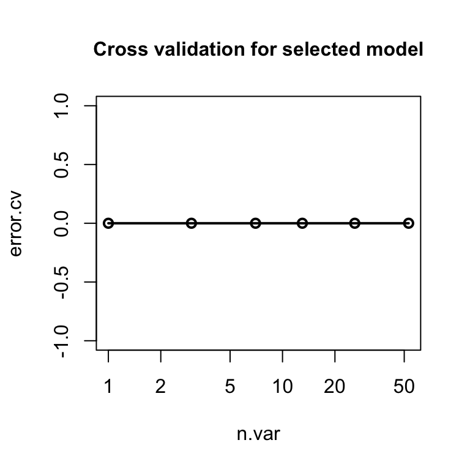

Finally, using the model we have predicted how well the exercise has been performed (classe) for the testing dataset (*validation set*) with the following results B, A, B, A, A, E, D, B, A, A, B, C, B, A, E, E, A, B, B, B, that coincide 20/20 with the validation set.

## Conclusions

The HAR dataset can be modeled using random forests to predict with high accuracy how well the barbell lifts exercise is being performed. The number of observations allows to create data subsets to assess out of sample errors. The dataset size make interesting the consideration of strategies to keep execution time under control.

## References

- This document has been generated using *knitr*, the markdown file can be found at: https://github.com/inesvidal/8ml-project/blob/gh-pages/index.Rmd
- The data for this project come from ‘Human Activity Recognition’ (HAR): Ugulino, W.; Cardador, D.; Vega, K.; Velloso, E.; Milidiu, R.; Fuks, H. Wearable Computing: Accelerometers’ Data Classification of Body Postures and Movements. Proceedings of 21st Brazilian Symposium on Artificial Intelligence. Advances in Artificial Intelligence - SBIA 2012. In: Lecture Notes in Computer Science. , pp. 52-61. Curitiba, PR: Springer Berlin / Heidelberg, 2012. ISBN 978-3-642-34458-9. DOI: 10.1007/978-3-642-34459-6_6. Read more: http://groupware.les.inf.puc-rio.br/har